# RNASeq Analysis

Victor Banerjee

2023-02-22

### The airway data

```r
data(airway)
# show the metadata
airway
```

```
## class: RangedSummarizedExperiment
## dim: 64102 8
## metadata(1): ''
## assays(1): counts
## rownames(64102): ENSG00000000003 ENSG00000000005 ... LRG_98 LRG_99
## rowData names(0):
## colnames(8): SRR1039508 SRR1039509 ... SRR1039520 SRR1039521
## colData names(9): SampleName cell ... Sample BioSample
```

```r
airway$dex
```

```
## [1] untrt trt   untrt trt   untrt trt   untrt trt
## Levels: trt untrt
```

```r
airway$cell
```

```
## [1] N61311  N61311  N052611 N052611 N080611 N080611 N061011 N061011
## Levels: N052611 N061011 N080611 N61311
```

```r
# First 10 transcripts
assay(airway, "counts")[1:10,]
```

```
##                 SRR1039508 SRR1039509 SRR1039512 SRR1039513 SRR1039516
## ENSG00000000003        679        448        873        408       1138
## ENSG00000000005          0          0          0          0          0
## ENSG00000000419        467        515        621        365        587
## ENSG00000000457        260        211        263        164        245
## ENSG00000000460         60         55         40         35         78
## ENSG00000000938          0          0          2          0          1
## ENSG00000000971       3251       3679       6177       4252       6721
## ENSG00000001036       1433       1062       1733        881       1424
## ENSG00000001084        519        380        595        493        820
## ENSG00000001167        394        236        464        175        658
##                 SRR1039517 SRR1039520 SRR1039521
## ENSG00000000003       1047        770        572
## ENSG00000000005          0          0          0
## ENSG00000000419        799        417        508
## ENSG00000000457        331        233        229
## ENSG00000000460         63         76         60
## ENSG00000000938          0          0          0
## ENSG00000000971      11027       5176       7995
## ENSG00000001036       1439       1359       1109
## ENSG00000001084        714        696        704
## ENSG00000001167        584        360        269
```

### Pre-Processing

The main variable of interest is dex which takes on levels trt (treated) and untrt (untreated). The first level will be the reference level for this factor, so we use relevel() to set the untrt level as reference; this is much easier to interpret.

```r
airway$dex
```

```
## [1] untrt trt   untrt trt   untrt trt   untrt trt
## Levels: trt untrt
```

```r
airway$dex <- relevel(airway$dex, "untrt")
airway$dex
```

```
## [1] untrt trt   untrt trt   untrt trt   untrt trt
## Levels: untrt trt
```

## DeSeq2 Analysis

```r
dds <- DESeqDataSet(airway, design = ~ cell + dex)
dds
```

```
## class: DESeqDataSet
## dim: 64102 8
## metadata(2): '' version
## assays(1): counts
## rownames(64102): ENSG00000000003 ENSG00000000005 ... LRG_98 LRG_99
## rowData names(0):
## colnames(8): SRR1039508 SRR1039509 ... SRR1039520 SRR1039521
## colData names(9): SampleName cell ... Sample BioSample
```

## Pre-filtering:

```r
dds <- dds [rowSums(counts(dds)) >= 50, ]
```

## Note on factor levels

By default, R will choose a reference level for factors based on alphabetical order. Then, if you never tell the DESeq2 functions which level you want to compare against (e.g. which level represents the control group), the comparisons will be based on the alphabetical order of the levels.

### Differential expression analysis

The standard differential expression analysis steps are wrapped into a single function, DESeq. The estimation steps performed by this function are described below, in the manual page for ?DESeq and in the Methods section of the DESeq2 publication (Love, Huber, and Anders 2014).

Results tables are generated using the function results, which extracts a results table with log2 fold changes, p values and adjusted p values. With no additional arguments to results, the log2 fold change and Wald test p value will be for the last variable in the design formula, and if this is a factor, the comparison will be the last level of this variable over the reference level (see previous note on factor levels). However, the order of the variables of the design do not matter so long as the user specifies the comparison to build a results table for, using the name or contrast arguments of results.

```r
dds <- DESeq(dds)
res <- results(dds, name="dex_trt_vs_untrt")
res
```

```
## log2 fold change (MLE): dex trt vs untrt
## Wald test p-value: dex trt vs untrt
## DataFrame with 17215 rows and 6 columns
##                  baseMean log2FoldChange     lfcSE      stat      pvalue
##                 <numeric>      <numeric> <numeric> <numeric>   <numeric>
## ENSG00000000003  709.6986     -0.3830735 0.1004616 -3.813133 1.37216e-04
## ENSG00000000419  521.0404      0.2050215 0.1112987  1.842083 6.54630e-02
## ENSG00000000457  237.5109      0.0361482 0.1406191  0.257065 7.97129e-01
## ENSG00000000460   58.0188     -0.0916461 0.2782425 -0.329375 7.41872e-01
## ENSG00000000971 5825.5137      0.4246038 0.0894392  4.747404 2.06044e-06
## ...                   ...            ...       ...       ...         ...
## ENSG00000273477   6.81686       0.429290  0.702641  0.610966    0.541222
## ENSG00000273478   6.72335       0.178467  0.660245  0.270304    0.786926
## ENSG00000273486  15.47469      -0.150509  0.468577 -0.321204    0.748056
## ENSG00000273487   8.17508       1.041274  0.675063  1.542484    0.122956
## ENSG00000273488   8.59577       0.110465  0.614551  0.179749    0.857350
##                        padj
##                   <numeric>
## ENSG00000000003 1.10561e-03
## ENSG00000000419 1.86488e-01
## ENSG00000000457 9.05422e-01
## ENSG00000000460 8.77333e-01
## ENSG00000000971 2.50675e-05
## ...                     ...
## ENSG00000273477    0.745182
## ENSG00000273478    0.900308
## ENSG00000273486    0.879630
## ENSG00000273487    0.295875
## ENSG00000273488    0.934664
```

## Log fold change shrinkage for visualization and ranking

Shrinkage of effect size (LFC estimates) is useful for visualization and ranking of genes. To shrink the LFC, we pass the dds object to the function lfcShrink. Below we specify to use the apeglm method for effect size shrinkage (Zhu, Ibrahim, and Love 2018), which improves on the previous estimator.

We provide the dds object and the name or number of the coefficient we want to shrink, where the number refers to the order of the coefficient as it appears in resultsNames(dds).

```r
resultsNames(dds)
```

```
## [1] "Intercept"               "cell_N061011_vs_N052611"
## [3] "cell_N080611_vs_N052611" "cell_N61311_vs_N052611"
## [5] "dex_trt_vs_untrt"
```

```r
resLFC <- lfcShrink(dds, coef="dex_trt_vs_untrt", type="apeglm")
```

```
## using 'apeglm' for LFC shrinkage. If used in published research, please cite:
##     Zhu, A., Ibrahim, J.G., Love, M.I. (2018) Heavy-tailed prior distributions for
##     sequence count data: removing the noise and preserving large differences.
##     Bioinformatics. https://doi.org/10.1093/bioinformatics/bty895
```

```r
resLFC
```

```
## log2 fold change (MAP): dex trt vs untrt
## Wald test p-value: dex trt vs untrt
## DataFrame with 17215 rows and 5 columns
##                  baseMean log2FoldChange     lfcSE      pvalue        padj
##                 <numeric>      <numeric> <numeric>   <numeric>   <numeric>
## ENSG00000000003  709.6986     -0.3607602 0.0998124 1.37216e-04 1.10561e-03
## ENSG00000000419  521.0404      0.1848607 0.1074316 6.54630e-02 1.86488e-01
## ENSG00000000457  237.5109      0.0303042 0.1287319 7.97129e-01 9.05422e-01
## ENSG00000000460   58.0188     -0.0515273 0.2113946 7.41872e-01 8.77333e-01
## ENSG00000000971 5825.5137      0.4091119 0.0893712 2.06044e-06 2.50675e-05
## ...                   ...            ...       ...         ...         ...
## ENSG00000273477   6.81686      0.0718701  0.299256    0.541222    0.745182
## ENSG00000273478   6.72335      0.0338141  0.287698    0.786926    0.900308
## ENSG00000273486  15.47469     -0.0468777  0.266111    0.748056    0.879630
## ENSG00000273487   8.17508      0.2160379  0.374550    0.122956    0.295875
## ENSG00000273488   8.59577      0.0223979  0.283078    0.857350    0.934664
```

# p-values and adjusted p-values

We can order our results table by the smallest p value,

```r
resOrdered <- res[order(res$pvalue),]
summary(res)
```

```
##
## out of 17215 with nonzero total read count
## adjusted p-value < 0.1
## LFC > 0 (up)       : 2637, 15%
## LFC < 0 (down)     : 2301, 13%
## outliers [1]       : 0, 0%
## low counts [2]     : 0, 0%
## (mean count < 5)
## [1] see 'cooksCutoff' argument of ?results
## [2] see 'independentFiltering' argument of ?results
```

How many adjusted p-values were less than 0.1?

```r
sum(res$padj < 0.1, na.rm=TRUE)
```

```
## [1] 4938
```

```r
res05 <- results(dds, alpha=0.05)
summary(res05)
```

```
##
## out of 17215 with nonzero total read count
## adjusted p-value < 0.05
## LFC > 0 (up)       : 2218, 13%
## LFC < 0 (down)     : 1882, 11%
## outliers [1]       : 0, 0%
## low counts [2]     : 0, 0%
## (mean count < 5)
## [1] see 'cooksCutoff' argument of ?results
## [2] see 'independentFiltering' argument of ?results
```

## Exploring and exporting results

### Dispersion plot and fitting alternatives

Plotting the dispersion estimates is a useful diagnostic. The dispersion plot below is typical, with the final estimates shrunk from the gene-wise estimates towards the fitted estimates. Some gene-wise estimates are flagged as outliers and not shrunk towards the fitted value, (this outlier detection is described in the manual page for estimateDispersionsMAP). The amount of shrinkage can be more or less than seen here, depending on the sample size, the number of coefficients, the row mean and the variability of the gene-wise estimates.

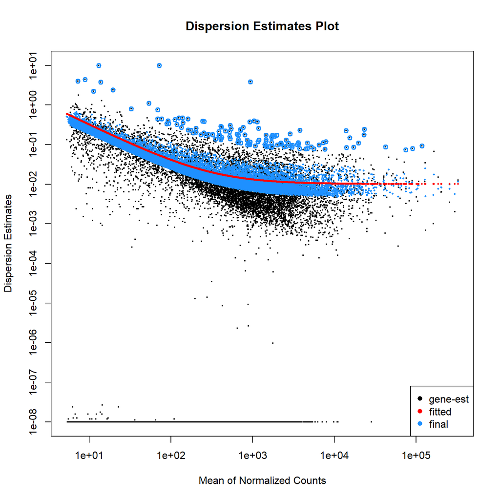

```r
plotDispEsts(dds, main = "Dispersion Estimates Plot",
             xlab = "Mean of Normalized Counts",
             ylab = "Dispersion Estimates")
```

### Data quality assessment by sample clustering and visualization

Data quality assessment and quality control (i.e. the removal of insufficiently good data) are essential steps of any data analysis. These steps should typically be performed very early in the analysis of a new data set, preceding or in parallel to the differential expression testing.

We define the term quality as fitness for purpose. Our purpose is the detection of differentially expressed genes, and we are looking in particular for samples whose experimental treatment suffered from an anormality that renders the data points obtained from these particular samples detrimental to our purpose.

### Heatmap of the count matrix

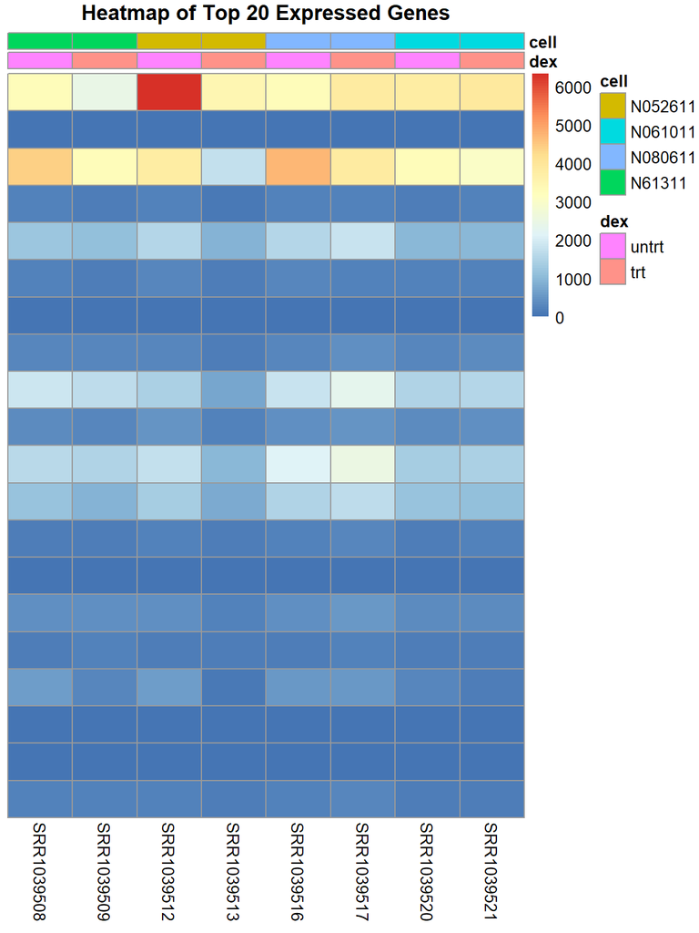

```r
library("pheatmap")

# Select the top 20 most highly expressed genes
select <- order(rowMeans(counts(dds,normalized=TRUE)),
                decreasing=TRUE)[1:20]

# Extract the "dex" and "cell" metadata columns from the colData object and convert to a data frame
df <- as.data.frame(colData(dds)[,c("dex","cell")])

# Generate the heatmap plot using pheatmap, with options to turn off row clustering, show column annotations,
# and use the "df" data frame as the column annotation data
pheatmap(assay(airway)[select,], cluster_rows=FALSE, show_rownames=FALSE,
         cluster_cols=FALSE, annotation_col=df,
         main = "Heatmap of Top 20 Expressed Genes",
         xlab = "Samples")
```

### Heatmap of the sample-to-sample distances Another use of the transformed data is sample clustering. Here, we apply the dist function to the transpose of the transformed count matrix to get sample-to-sample distances.

```r
vsd <- vst(dds, blind=FALSE)
head(vsd)
```

```
## class: DESeqTransform
## dim: 6 8
## metadata(2): '' version
## assays(1): ''
## rownames(6): ENSG00000000003 ENSG00000000419 ... ENSG00000000971
##   ENSG00000001036
## rowData names(34): baseMean baseVar ... maxCooks dispFit
## colnames(8): SRR1039508 SRR1039509 ... SRR1039520 SRR1039521
## colData names(10): SampleName cell ... BioSample sizeFactor
```

```r
sampleDists <- dist(t(assay(vsd)))
```

A heatmap of this distance matrix gives us an overview over similarities and dissimilarities between samples. We have to provide a hierarchical clustering hc to the heatmap function based on the sample distances, or else the heatmap function would calculate a clustering based on the distances between the rows/columns of the distance matrix.

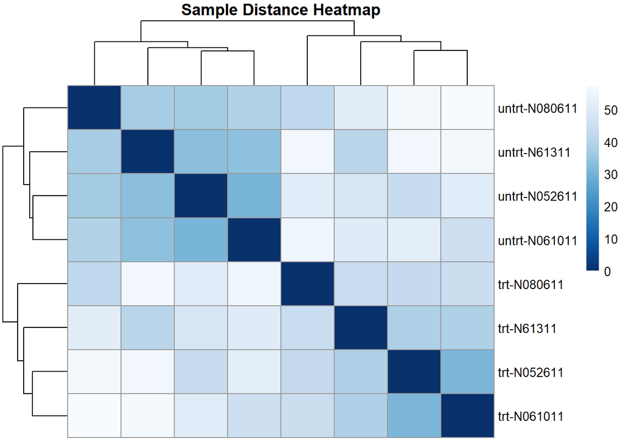

```r
library("RColorBrewer")  # Load the RColorBrewer package for color palettes

# Convert the sample distance matrix to a matrix and set the row names to a combination of "dex" and "cell" metadata columns
sampleDistMatrix <- as.matrix(sampleDists)
rownames(sampleDistMatrix) <- paste(vsd$dex, vsd$cell, sep="-")

# Set the column names to NULL to prevent them from being displayed in the heatmap
colnames(sampleDistMatrix) <- NULL

# Create a color palette for the heatmap using the colorRampPalette and brewer.pal functions
colors <- colorRampPalette( rev(brewer.pal(9, "Blues")) )(255)

# Generate the heatmap plot using pheatmap, with options to cluster rows and columns by sample distance and use the "colors" palette for the color scale
pheatmap(sampleDistMatrix,
         clustering_distance_rows=sampleDists,
         clustering_distance_cols=sampleDists,
         col=colors,
         main = "Sample Distance Heatmap",  # Add a title to the plot
         xlab = "Sample ID",  # Change the x-axis label to "Sample ID"
         ylab = "Sample ID")  # Change the y-axis label to "Sample ID"
```

### Principal component plot of the samples

Related to the distance matrix is the PCA plot, which shows the samples in the 2D plane spanned by their first two principal components. This type of plot is useful for visualizing the overall effect of experimental covariates and batch effects.

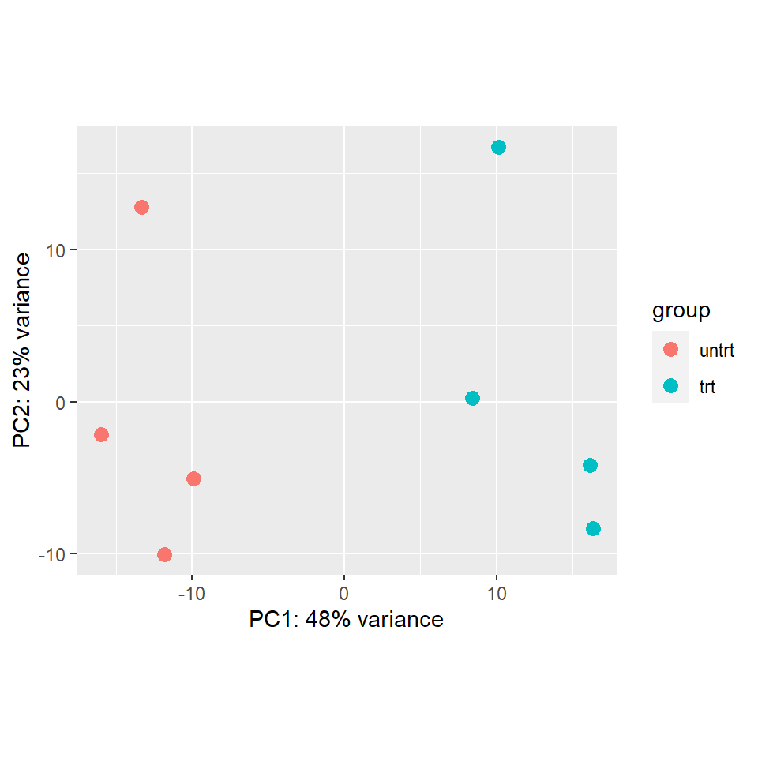

```r
plotPCA(vsd, intgroup=c("dex"))
```

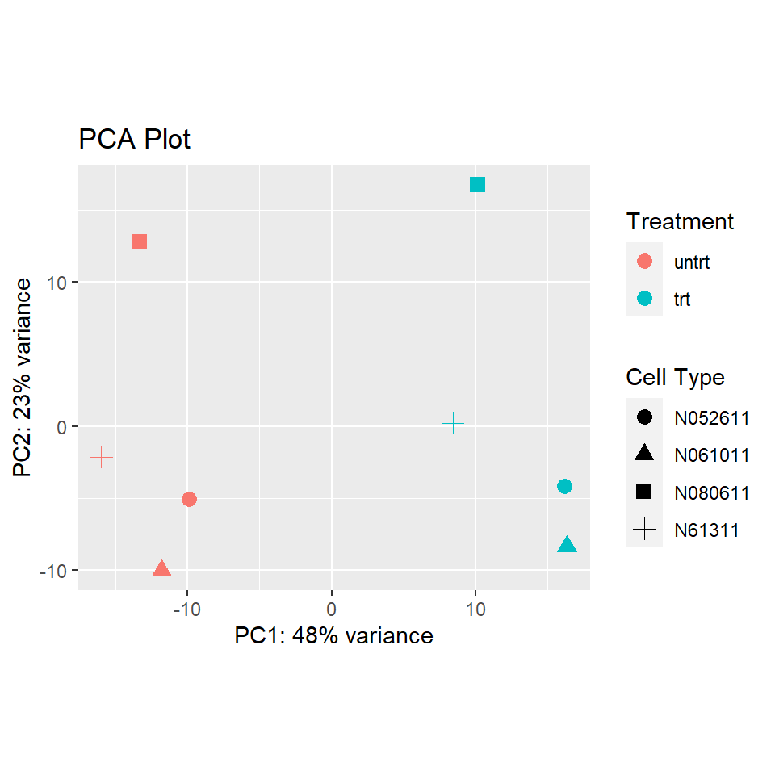

```r
pcaData <- plotPCA(vsd, intgroup=c("dex", "cell"), returnData=TRUE)
percentVar <- round(100 * attr(pcaData, "percentVar"))
ggplot(pcaData, aes(PC1, PC2, color=dex, shape=cell)) +
  geom_point(size=3) +
  xlab(paste0("PC1: ",percentVar[1],"% variance")) +
  ylab(paste0("PC2: ",percentVar[2],"% variance")) +
  coord_fixed() +
  labs(title = "PCA Plot",
       color = "Treatment",
       shape = "Cell Type")
```

### Annotating and exporting results

Our result table so far only contains the Ensembl gene IDs, but alternative gene names may be more informative for interpretation. Bioconductor’s annotation packages help with mapping various ID schemes to each other. We load the AnnotationDbi package and the annotation package org.Hs.eg.db: This is the organism annotation package (“org”) for Homo sapiens (“Hs”), organized as an AnnotationDbi database package (“db”), using Entrez Gene IDs (“eg”) as primary key. To get a list of all available key types, use:

```r
library("AnnotationDbi")
library("org.Hs.eg.db")
columns(org.Hs.eg.db)
```

```
##  [1] "ACCNUM"       "ALIAS"        "ENSEMBL"      "ENSEMBLPROT"  "ENSEMBLTRANS"
##  [6] "ENTREZID"     "ENZYME"       "EVIDENCE"     "EVIDENCEALL"  "GENENAME"
## [11] "GENETYPE"     "GO"           "GOALL"        "IPI"          "MAP"
## [16] "OMIM"         "ONTOLOGY"     "ONTOLOGYALL"  "PATH"         "PFAM"
## [21] "PMID"         "PROSITE"      "REFSEQ"       "SYMBOL"       "UCSCKG"
## [26] "UNIPROT"
```

We can use the mapIds function to add individual columns to our results table. We provide the row names of our results table as a key, and specify that keytype=ENSEMBL. The column argument tells the mapIds function which information we want, and the multiVals argument tells the function what to do if there are multiple possible values for a single input value. Here we ask to just give us back the first one that occurs in the database. To add the gene symbol and Entrez ID, we call mapIds twice.

```r
ens.str <- substr(rownames(res), 1, 15)
res$symbol <- mapIds(org.Hs.eg.db,
                     keys=ens.str,
                     column="SYMBOL",
                     keytype="ENSEMBL",
                     multiVals="first")
res$entrez <- mapIds(org.Hs.eg.db,
                     keys=ens.str,
                     column="ENTREZID",
                     keytype="ENSEMBL",
                     multiVals="first")
res$ENSEMBL <- rownames(res)
resOrdered <- res[order(res$pvalue),]
head(resOrdered)
```

```
## log2 fold change (MLE): dex trt vs untrt
## Wald test p-value: dex trt vs untrt
## DataFrame with 6 rows and 9 columns
##                  baseMean log2FoldChange     lfcSE      stat       pvalue
##                 <numeric>      <numeric> <numeric> <numeric>    <numeric>
## ENSG00000165995   495.717        3.28940  0.132351   24.8535 2.36821e-136
## ENSG00000152583   998.348        4.57317  0.184377   24.8034 8.24545e-136
## ENSG00000120129  3412.852        2.94607  0.122541   24.0415 1.02406e-127
## ENSG00000101347 12718.190        3.76522  0.157064   23.9725 5.38043e-127
## ENSG00000189221  2344.092        3.35194  0.142696   23.4900 5.16531e-122
## ENSG00000211445 12302.453        3.72865  0.167633   22.2430 1.31825e-109
##                         padj      symbol      entrez         ENSEMBL
##                    <numeric> <character> <character>     <character>
## ENSG00000165995 4.07688e-132      CACNB2         783 ENSG00000165995
## ENSG00000152583 7.09727e-132     SPARCL1        8404 ENSG00000152583
## ENSG00000120129 5.87639e-124       DUSP1        1843 ENSG00000120129
## ENSG00000101347 2.31560e-123      SAMHD1       25939 ENSG00000101347
## ENSG00000189221 1.77842e-118        MAOA        4128 ENSG00000189221
## ENSG00000211445 3.78227e-106        GPX3        2878 ENSG00000211445
```

### MAplot

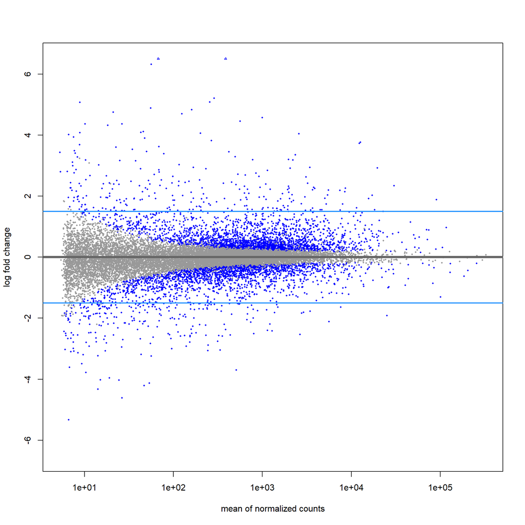

```r
ylim <- c(-6.5,6.5)
drawLines <- function() abline(h=c(-1.5,1.5),col="dodgerblue",lwd=2)
DESeq2::plotMA(resOrdered, ylim=ylim); drawLines()
```

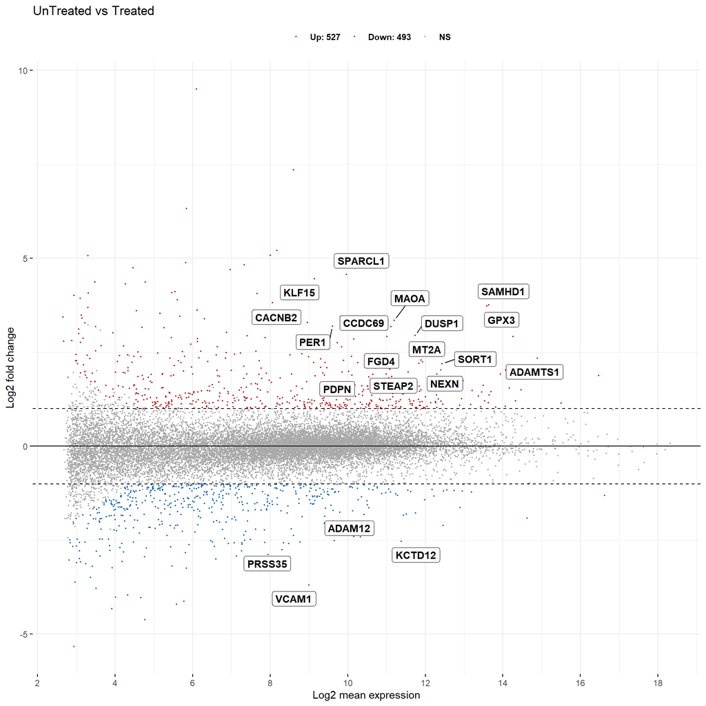

```r
#install.packages("ggpubr")
library(ggpubr)

# Add rectangle around labels
ggmaplot(resOrdered, main = expression("UnTreated vs Treated"),
   fdr = 0.05, fc = 2, size = 0.4,
   palette = c("#B31B21", "#1465AC", "darkgray"),
   genenames = as.vector(resOrdered$symbol),
   legend = "top", top = 20,
   font.label = c("bold", 11), label.rectangle = TRUE,
   font.legend = "bold",
   font.main = "bold",
   ggtheme = ggplot2::theme_minimal())
```

### Enahansed volacano

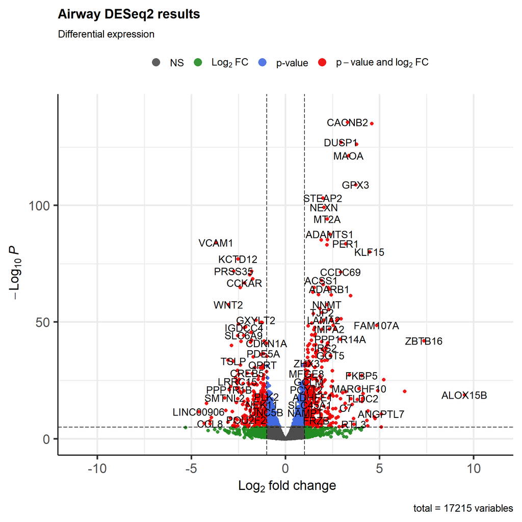

```r
library(EnhancedVolcano)
EnhancedVolcano(resOrdered,
                lab = resOrdered$symbol,
                x = 'log2FoldChange',
                y = 'pvalue',
                xlim = c(-11, 11),
                title = 'Airway DESeq2 results',
                subtitle = 'Differential expression',
                legendPosition = "top",
                col = c('grey30', 'forestgreen', 'royalblue', 'red2'),
                colAlpha = 0.9,
                )
```

```r
library("genefilter")
```

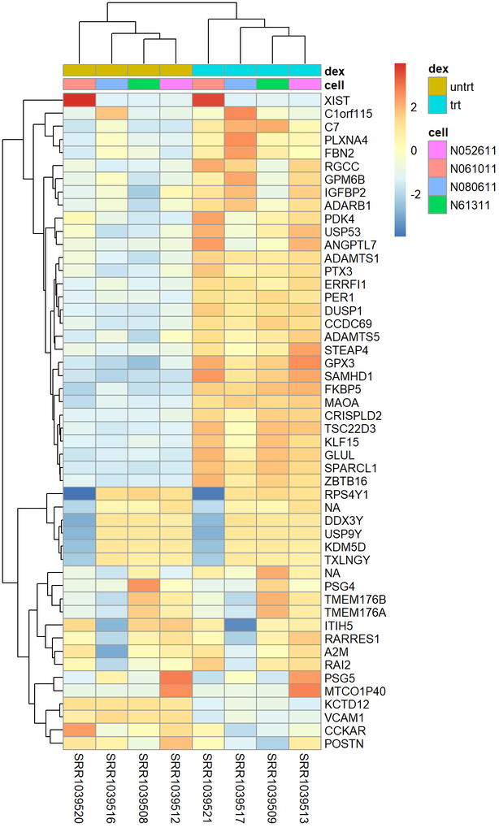

```r
topVarGenes <- head(order(rowVars(assay(vsd)), decreasing = TRUE), 50)
mat  <- assay(vsd)[ topVarGenes, ]
mat  <- mat - rowMeans(mat)
ens.str <- substr(rownames(mat), 1, 15)
rownames(mat) <- mapIds(org.Hs.eg.db,
                     keys=ens.str,
                     column="SYMBOL",
                     keytype="ENSEMBL",
                     multiVals="first")
anno <- as.data.frame(colData(vsd)[, c("cell","dex")])
pheatmap(mat, annotation_col = anno)
```

### Exporting results

A more sophisticated way for exporting results the Bioconductor package ReportingTools (Huntley et al. 2013). ReportingTools will automatically generate dynamic HTML documents, including links to external databases using gene identifiers and boxplots summarizing the normalized counts across groups. See the ReportingTools vignettes for full details. The simplest version of creating a dynamic ReportingTools report is performed with the following code:

```r
#BiocManager::install("ReportingTools")
library("ReportingTools")
resOrderedDF <- as.data.frame(resOrdered)[1:100, ]
write.csv(resOrderedDF, file = "results.csv")

htmlRep <- HTMLReport(shortName="report", title="My report",
                      reportDirectory="./report")

publish(resOrderedDF, htmlRep)
#url <- finish(htmlRep)
#browseURL(url)
```

### Saving The Files:

```r
write.table(res, file='results_airway.tsv', sep="\t", quote=FALSE, row.names=TRUE)
```